# Becoming the Very Best API: Contacting the pokeAPI

### `The People's Champ: Sinnoh Region`

```r
sinnoh <- pokeAPI("gen", 4)
sinnoh <- sinnoh %>% mutate(totalstats = hp+attack+defense+special.attack+special.defense+speed)
head(sinnoh)
```

```
##        name pokedex_id          type  ability weight hp attack defense special.attack special.defense
## 1   turtwig        387         grass overgrow    102 55     68      64             45              55
## 2    grotle        388         grass overgrow    970 75     89      85             55              65
## 3  torterra        389  grass/ground overgrow   3100 95    109     105             75              85
## 4  chimchar        390          fire    blaze     62 44     58      44             58              44
## 5  monferno        391 fire/fighting    blaze    220 64     78      52             78              52
## 6 infernape        392 fire/fighting    blaze    550 76    104      71            104              71
##   speed catch_rate_pct totalstats
## 1    31             18        318
## 2    36             18        405
## 3    56             18        525
## 4    61             18        309
## 5    81             18        405
## 6   108             18        534
```

Let’s look at the strongest pokemon. As always, legendaries will be a good portion of the list, but let’s see if there are any surprising additions.

[figure not shown]

```r
sinnoh_strongest <- top_n(sinnoh, n=25, totalstats)

plot15 <- ggplot(sinnoh_strongest, aes(x=name, y=totalstats, fill=type)) + geom_bar(stat='identity') + coord_flip() + ggtitle("Strongest Sinnoh Pokemon") + xlab("Pokemon Name") + ylab("Total Stats") + theme(plot.title = element_text(hjust = 0.5))
plot15
```

Again, the three starters and many of the legendaries are present. I have half a mind to not count `Arceus` since it is the literal god of pokemon and can technically be any single type of pokemon. Many of the pokemon on this list have unique typing or are pseudo/actual legendary pokemon. With the even smaller pool of pokemon present that are unique to this generation, it will be a bit tougher to analyze type.

[figure not shown]

```r
plot16 <- ggplot(sinnoh_strongest, aes(x=name, y=catch_rate_pct, fill=type)) + geom_bar(stat='identity') + coord_flip() + ggtitle("Strongest Sinnoh Pokemon Catch Rate") + xlab("Pokemon Name") + ylab("Catch Rate %") + theme(plot.title = element_text(hjust = 0.5))
plot16
```

Interestingly, `Probopass` and `Hippowdon` are the two pokemon with the highest `catch_rate`. Let’s look at the `totalstats` spread.

[figure not shown]

```r
plot17 <- ggplot(hoenn, aes(x=totalstats))  + geom_histogram() + xlab("Total Stats") + ylab("Count") + theme(plot.title = element_text(hjust = 0.5))
plot17
```

Once more, we’ll look at the breakdown of `totalstats` in Sinnoh by type, as well as overall summary.

```r
sinnoh %>% group_by(type) %>% summarise(avg = round(mean(totalstats)), med = median(totalstats), var = round(var(totalstats)))
```

```
## # A tibble: 48 × 4
##    type             avg   med   var
##    <chr>          <dbl> <dbl> <dbl>
##  1 bug              267   224 10433
##  2 bug/flying       414   449 14267
##  3 bug/grass        424   424    NA
##  4 dark             600   600    NA
##  5 dark/flying      505   505    NA
##  6 dark/ice         510   510    NA
##  7 dragon/ground    437   410 23033
##  8 electric         419   405 13281
##  9 electric/ghost   440   440    NA
## 10 electric/steel   535   535    NA
## # … with 38 more rows
```

```r
summary(sinnoh$totalstats)
```

```
##    Min. 1st Qu.  Median    Mean 3rd Qu.    Max.
##   194.0   337.0   480.0   445.8   525.0   720.0
```

Compared to the other two generations, the mean and median `totalstats` for Sinnoh is a lot higher.

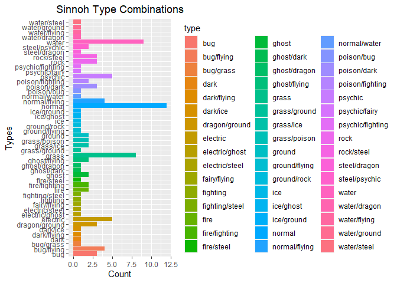

```r
plot18 <- ggplot(sinnoh, aes(x=type, fill=type))  + geom_bar() + coord_flip() + ggtitle("Sinnoh Type Combinations") + xlab("Types") + ylab("Count") + theme(plot.title = element_text(hjust = 0.5))
plot18
```

The spread seems a bit similar to Hoenn, with `Water`, `Normal`, `Psychic`, `Grass`, and `Electric` being the most prevalent. Time to dive into their stats.

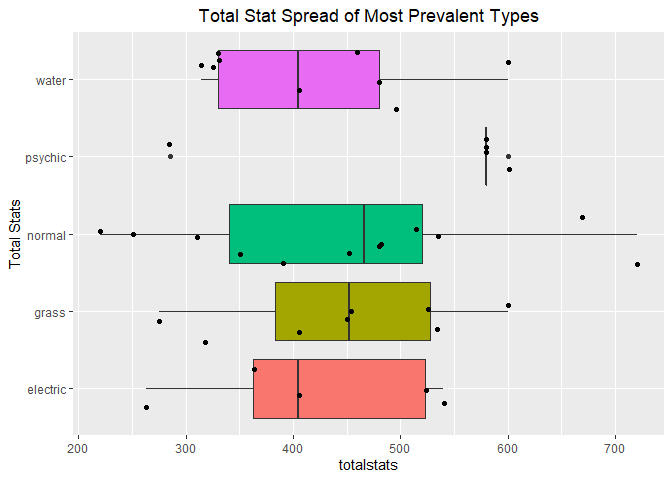

```r
sinnoh_spread <- filter(sinnoh, type == 'water' | type == 'normal' | type == 'grass' | type == 'psychic' | type == 'electric')

plot19 <- ggplot(sinnoh_spread, aes(x=type, y=totalstats, fill=type)) + geom_boxplot(show.legend = FALSE) + geom_jitter(shape=16) + coord_flip() + theme(legend.position = "none", plot.title = element_text(hjust = 0.5)) + ggtitle("Total Stat Spread of Most Prevalent Types") + xlab("Total Stats")
plot19
```

`Normal` has the highest spread but `Psychic` has the highest overall mean for `totalstats` (even though there weren’t many observations). Let’s check the relationship between both `attack`/`defense`/ and `special attack`/`special defense`.

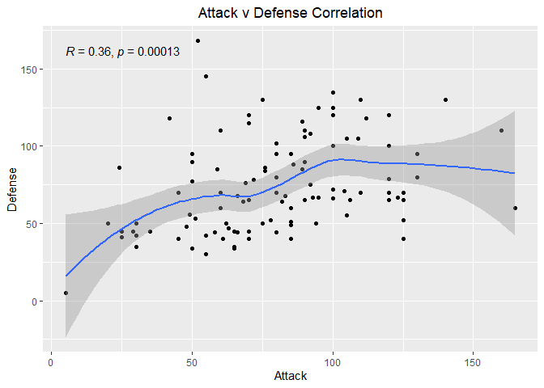

```r
plot20 <- ggplot(sinnoh, aes(x=attack, y=defense)) + geom_point(stat='identity') + geom_smooth() + stat_cor(mapping = NULL, data = NULL, method = "pearson", alternative = "two.sided") + ggtitle("Attack v Defense Correlation") + xlab("Attack") + ylab("Defense") + theme(plot.title = element_text(hjust = 0.5))
plot20
```

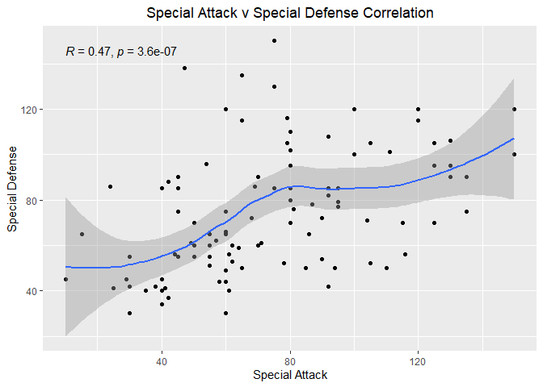

```r
plot21 <- ggplot(sinnoh, aes(x=special.attack, y=special.defense)) + geom_point(stat='identity') + geom_smooth() + stat_cor(mapping = NULL, data = NULL, method = "pearson", alternative = "two.sided") + ggtitle("Special Attack v Special Defense Correlation") + xlab("Special Attack") + ylab("Special Defense") + theme(plot.title = element_text(hjust = 0.5))
plot21
```

Lastly, let’s check the `speed` breakdown of the types we focused on.

[figure not shown]

```r
plot22 <- ggplot(sinnoh_spread, aes(x=type, y=speed, fill=type)) + geom_boxplot(show.legend = FALSE) + geom_jitter(shape=16) + coord_flip() + theme(legend.position = "none") + ggtitle("Kanto Speed of Most Prevalent Types") + xlab("Types") + ylab("Speed Stat") + theme(plot.title = element_text(hjust = 0.5))
plot22
```

## Conclusion/Future Expectations

While I did find certain pokemon to be stronger than others, I still don’t hae enough information to adequately say which pokemon are “the strongest”. I focused in on the types of pokemon that were most prevalent, and their `totalstats` spreads, but I did not look into type combinations that were less in number but could have had a more extensive skillset or higher overall stats. Legendaries of course were the strongest, but pokemon such as `Slaking`, a `Normal` type pokemon that anyone can catch in its base form, was second-strongest in `Generation 3`, only trailing `Rayquaza`, which is one of the strongest pokemon ever introduced. In the future, I would like to come up with some kind of calculation incorporating `capture_rate`, `totalstats`, and another variable `encounter_rate`, that can give a base metric on which pokemon are must-haves based on the generation.